# R: Probe a partially-observed Markov process by computing...

| Probes and synthetic likelihood {pomp} | R Documentation |
| --- | --- |

## Probe a partially-observed Markov process by computing summary statistics and the synthetic likelihood.

### Description

`probe` applies one or more “probes” to time series data and model simulations and compares the results. It can be used to diagnose goodness of fit and/or as the basis for “probe-matching”, a generalized method-of-moments approach to parameter estimation. `probe.match` calls an optimizer to adjust model parameters to do probe-matching, i.e., to minimize the discrepancy between simulated and actual data. This discrepancy is measured using the “synthetic likelihood” as defined by Wood (2010). `probe.match.objfun` constructs an objective function for probe-matching suitable for use in `optim`-like optimizers.

### Usage

```
## S4 method for signature 'pomp'
probe(object, probes, params, nsim, seed = NULL, ...)
## S4 method for signature 'probed.pomp'
probe(object, probes, params, nsim, seed, ...)
## S4 method for signature 'pomp'
probe.match.objfun(object, params, est, probes, nsim,
            seed = NULL, fail.value = NA, transform = FALSE, ...)
## S4 method for signature 'probed.pomp'
probe.match.objfun(object, probes, nsim, seed, ...)
## S4 method for signature 'pomp'
probe.match(object, start, est = character(0),
            probes, nsim, seed = NULL,
            method = c("subplex","Nelder-Mead","SANN","BFGS",
                       "sannbox","nloptr"),
            verbose = getOption("verbose"),
            fail.value = NA, transform = FALSE, ...)
## S4 method for signature 'probed.pomp'
probe.match(object, probes, nsim, seed,
            ..., verbose = getOption("verbose"))
## S4 method for signature 'probe.matched.pomp'
probe.match(object, est, probes,
            nsim, seed, transform, fail.value, ...,
            verbose = getOption("verbose"))
## S4 method for signature 'probed.pomp'
logLik(object, ...)
## S4 method for signature 'probed.pomp'
values(object, ...)
```

### Arguments

[output not shown]

### Details

A call to `probe` results in the evaluation of the probe(s) in `probes` on the data. Additionally, `nsim` simulated data sets are generated (via a call to `simulate`) and the probe(s) are applied to each of these. The results of the probe computations on real and simulated data are stored in an object of class `probed.pomp`.

A call to `probe.match` results in an attempt to optimize the agreement between model and data, as measured by the specified probes, over the parameters named in `est`. The results, including coefficients of the fitted model and values of the probes for data and fitted-model simulations, are stored in an object of class `probe.matched.pomp`.

The objective function minimized by `probe.match` — in a form suitable for use with `optim`-like optimizers — is created by a call to `probe.match.objfun`. Specifically, `probe.match.objfun` will return a function that takes a single numeric-vector argument that is assumed to cotain the parameters named in `est`, in that order. This function will return the negative synthetic log likelihood for the probes specified.

### Value

`probe` returns an object of class `probed.pomp`. `probed.pomp` is derived from the `pomp` class and therefore have all the slots of `pomp`. In addition, a `probed.pomp` class has the following slots:

**probes**

list of the probes applied.

**datvals, simvals**

values of each of the probes applied to the real and simulated data, respectively.

**quantiles**

fraction of simulations with probe values less than the value of the probe of the data.

**pvals**

two-sided p-values: fraction of the `simvals` that deviate more extremely from the mean of the `simvals` than does `datavals`.

**synth.loglik**

the log synthetic likelihood (Wood 2010). This is the likelihood assuming that the probes are multivariate-normally distributed.

`probe.match` returns an object of class `probe.matched.pomp`, which is derived from class `probed.pomp`. `probe.matched.pomp` objects therefore have all the slots above plus the following:

**est, transform, fail.value**

values of the corresponding arguments in the call to `probe.match`.

**value**

value of the objective function at the optimum.

**evals**

number of function and gradient evaluations by the optimizer. See `optim`.

**convergence, msg**

Convergence code and message from the optimizer. See `optim` and `nloptr`.

`probe.match.objfun` returns a function suitable for use as an objective function in an `optim`-like optimizer.

### Methods

**plot**

displays diagnostic plots.

**summary**

displays summary information.

**values**

extracts the realized values of the probes on the data and on the simulations as a data frame in long format. The variable `.id` indicates whether the probes are from the data or simulations.

**logLik**

returns the synthetic likelihood for the probes. NB: in general, this is not the same as the likelihood.

**as, as.data.frame**

when a ‘probed.pomp’ is coerced to a ‘data.frame’, the first row gives the probes applied to the data; the rest of the rows give the probes evaluated on simulated data. The rownames of the result can be used to distinguish these.

In addition, slots of this object can be accessed via the `$` operator.

### Author(s)

Daniel C. Reuman, Aaron A. King

### References

B. E. Kendall, C. J. Briggs, W. M. Murdoch, P. Turchin, S. P. Ellner, E. McCauley, R. M. Nisbet, S. N. Wood Why do populations cycle? A synthesis of statistical and mechanistic modeling approaches, Ecology, 80:1789–1805, 1999.

S. N. Wood Statistical inference for noisy nonlinear ecological dynamic systems, Nature, 466: 1102–1104, 2010.

### See Also

pomp, probe functions, spect, and the tutorials on the [package website](http://pomp.r-forge.r-project.org).

### Examples

```r
pompExample(ou2)
```

```
## newly created object(s):
##  ou2
```

```r
good <- probe(
              ou2,
              probes=list(
                y1.mean=probe.mean(var="y1"),
                y2.mean=probe.mean(var="y2"),
                y1.sd=probe.sd(var="y1"),
                y2.sd=probe.sd(var="y2"),
                extra=function(x)max(x["y1",])
                ),
              nsim=500
              )
summary(good)
```

```
## $coef
## alpha.1 alpha.2 alpha.3 alpha.4 sigma.1 sigma.2 sigma.3     tau    x1.0
##     0.8    -0.5     0.3     0.9     3.0    -0.5     2.0     1.0    -3.0
##    x2.0
##     4.0
##
## $nsim
## [1] 500
##
## $quantiles
## y1.mean y2.mean   y1.sd   y2.sd   extra
##   0.152   0.534   0.052   0.074   0.084
##
## $pvals
##   y1.mean   y2.mean     y1.sd     y2.sd     extra
## 0.3073852 0.9341317 0.1077844 0.1516966 0.1716567
##
## $synth.loglik
## [1] -6.053158
```

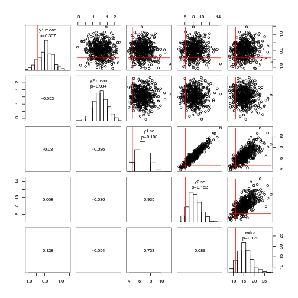

```r
plot(good)
```

```r
bad <- probe(
             ou2,
             params=c(alpha.1=0.1,alpha.4=0.2,x1.0=0,x2.0=0,
                      alpha.2=-0.5,alpha.3=0.3,
                      sigma.1=3,sigma.2=-0.5,sigma.3=2,
                      tau=1),
             probes=list(
               y1.mean=probe.mean(var="y1"),
               y2.mean=probe.mean(var="y2"),
               y1.sd=probe.sd(var="y1"),
               y2.sd=probe.sd(var="y2"),
               extra=function(x)range(x["y1",])
               ),
             nsim=500
             )
summary(bad)
```

```
## $coef
## alpha.1 alpha.4    x1.0    x2.0 alpha.2 alpha.3 sigma.1 sigma.2 sigma.3
##     0.1     0.2     0.0     0.0    -0.5     0.3     3.0    -0.5     2.0
##     tau
##     1.0
##
## $nsim
## [1] 500
##
## $quantiles
## y1.mean y2.mean   y1.sd   y2.sd  extra1  extra2
##   0.062   0.606   1.000   1.000   0.040   0.970
##
## $pvals
##     y1.mean     y2.mean       y1.sd       y2.sd      extra1      extra2
## 0.127744511 0.790419162 0.003992016 0.003992016 0.083832335 0.063872255
##
## $synth.loglik
## [1] -115.0439
```

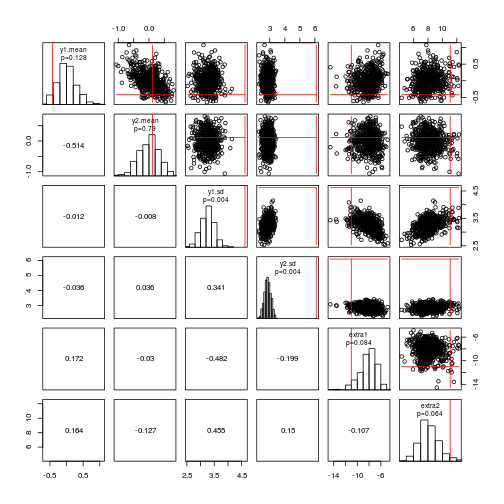

```r
plot(bad)
```

[Package *pomp* version 0.62-5 Index]